# Reproducible Research 1 Steps

Chandrashekar Baskaran July 2017

This is the first document in the Reproducible Research course in Coursera’s Introduction to Data Science track

### Aim:

The purpose of the project was to execute: - Loading and Preprocessing data - Impute missing values - Answer research questions

### Data:

The data for this assignment can be downloaded from the course web site:

- Dataset: [Activity monitoring data](https://d396qusza40orc.cloudfront.net/repdata%2Fdata%2Factivity.zip) [52K]

The variables included in this dataset are:

- steps: Number of steps taking in a 5-minute interval (missing values are coded as NA)
- date: The date on which the measurement was taken in YYYY-MM-DD format
- interval: Identifier for the 5-minute interval in which measurement was taken

The dataset is stored in a comma-separated-value (CSV) file and there are a total of 17,568 observations in this dataset.

### Loading and Preprocessing the Data:

Download,unzip the data provided and load it into data frame data.

```r
require(downloader)
```

```r
dataset_url <- "https://d396qusza40orc.cloudfront.net/repdata%2Fdata%2Factivity.zip"
download.file(dataset_url,dest="data.zip", mode="wb")
unzip("data.zip", exdir="./")
data<-read.csv("activity.csv")
```

#### What is mean total number of steps taken per day?

Sum steps per day, create histogram and compute mean and median

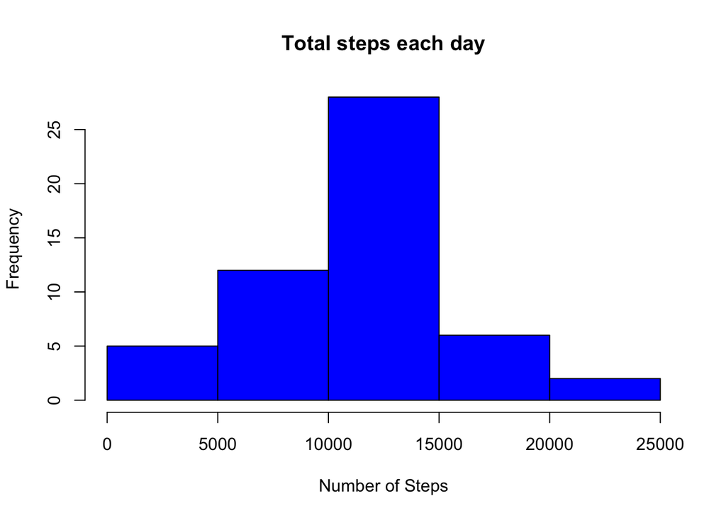

```r
steps_by_day <- aggregate(steps ~ date,data,sum)
hist(steps_by_day$steps, main=paste("Total steps each day"), col= "blue",xlab = "Number of Steps")
```

```r
rmean <- mean(steps_by_day$steps)
rmedian <- median(steps_by_day$steps)
```

The mean is 1.076618910^{4} and the median is 10765

##### What is the average daily activity pattern?

Plot a time series with average steps taken and compute which 5 minute interval has maximum steps

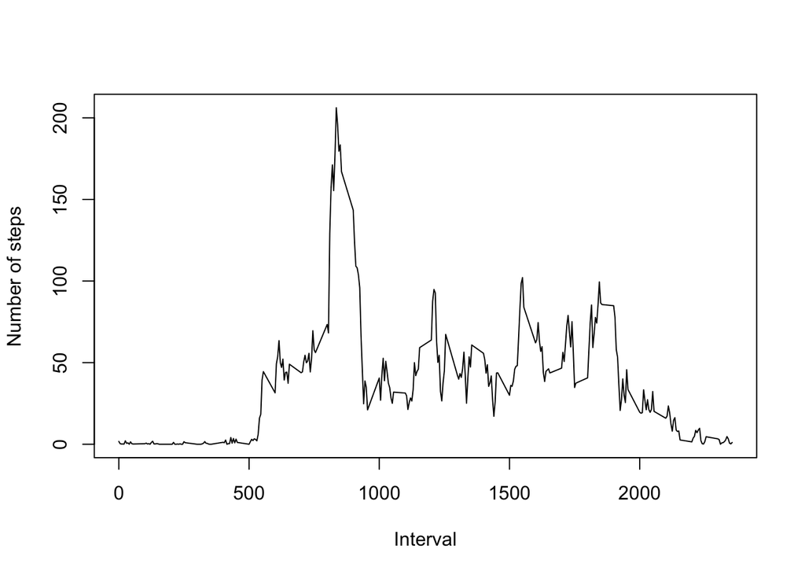

```r
steps_by_interval<-aggregate(steps~interval, data, mean)
plot(steps_by_interval$interval, steps_by_interval$steps, type= "l", xlab="Interval", ylab = "Number of steps")
```

```r
max_interval<-steps_by_interval[which.max(steps_by_interval$steps),1]
```

The 5-minute interval on an average across all days containing maximum number of steps is 835

#### Impute missing values and compare imputed and non imputed data

Missing values need to be imputed. A simple approach was used here where we substitute the missing values with the average for each interval.

```r
incomplete<-sum(!complete.cases(data))
imputed_data <- transform(data, steps = ifelse(is.na(data$steps),steps_by_interval$steps[match(data$interval,steps_by_interval$interval)],data$steps))
```

Zeroes were imputed for data 10/01/2012 as it was the first day

```r
imputed_data[as.character(imputed_data$date)=="2012-10-01",1]<-0
```

Recount total steps by day to create histogram to show the difference

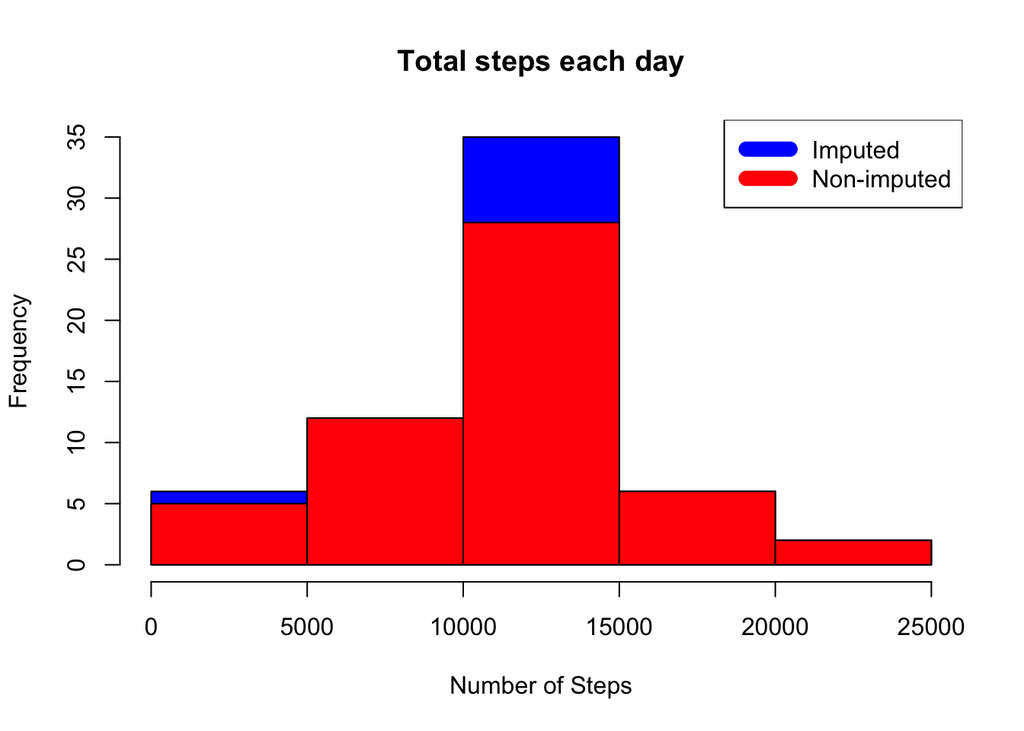

```r
steps_by_day_i <- aggregate(steps~date,imputed_data,sum)
hist(steps_by_day_i$steps, main=paste("Total steps each day"),col="blue",xlab="Number of Steps")
hist(steps_by_day$steps, main=paste("Total steps each day"), col= "red",xlab = "Number of Steps",add = T)
legend("topright", c("Imputed", "Non-imputed"), col=c("blue", "red"), lwd=10)
```

Calculate the new mean and median

```r
rmean.i <- mean(steps_by_day_i$steps)
rmedian.i <- median(steps_by_day_i$steps)
```

Calculate difference between imputed and non-imputed data

```r
mean_diff <- rmean.i - rmean
med_diff <- rmedian.i - rmedian
```

Calculate the total difference

```r
total_diff <- sum(steps_by_day_i$steps) - sum(steps_by_day$steps)
```

- The imputed data mean is 1.058969410^{4}
- The imputed data median is 1.076618910^{4}
- The difference between non-imputed and imputed mean is -176.4948964
- The difference between non-imputed and imputed median is 1.1886792
- The difference between total number of steps between imputed and non-imputed data is 7.536332110^{4}. There were 7.536332110^{4} more steps in imputed data

#### Are there differences in activity patterns between weekdays and weekends?

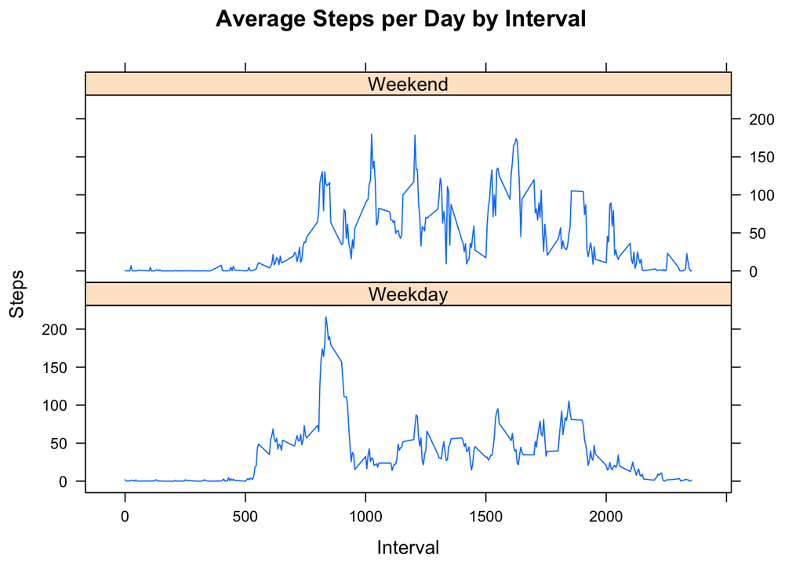

```r
weekdays <- c("Monday","Tuesday","Wednesday","Thursday","Friday", "Saturday")
imputed_data$dow = as.factor(ifelse(is.element(weekdays(as.Date(imputed_data$date)),weekdays), "Weekday", "Weekend"))
steps_by_interval_i <- aggregate(steps ~ interval + dow, imputed_data, mean)
library(lattice)
xyplot(steps_by_interval_i$steps ~ steps_by_interval_i$interval|steps_by_interval_i$dow, main="Average Steps per Day by Interval",xlab="Interval", ylab="Steps",layout=c(1,2), type="l")
```